# Intro R Workshop: Exercise 2

true

AJ Smit

17 March 2021

# 1. The SACTNmonthly_v4.0.RData (A)

Please *exactly* recreate the figure immediately below (you may use your own colour for the line). Note: in order to calculate a yearly mean for each of the data points within a year, you will have to use one of the functions in the **lubridate** package. There is also the `mutate()` function (within the **dplyr** package) that I have mentioned before, but which we have not explicitely practiced — it will have to be used to receive the result of the **lubridate** function that I alluded to above.

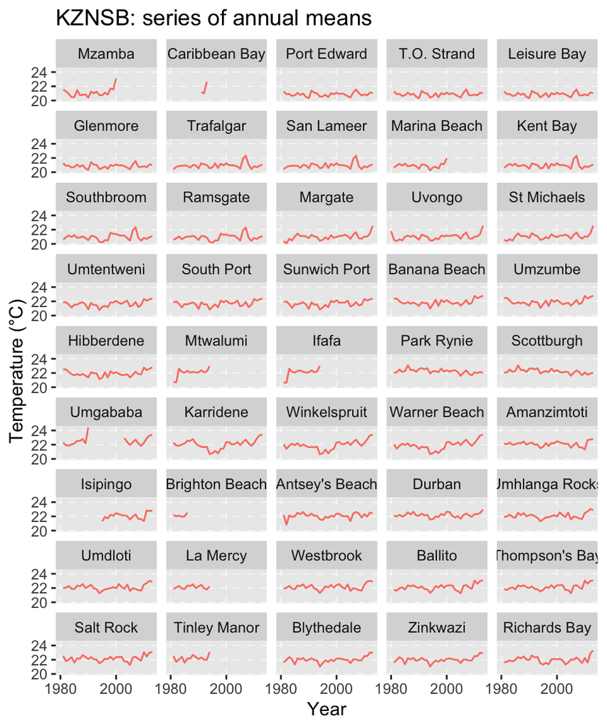

# 2. The SACTNmonthly_v4.0.RData (B)

Please produce a series of graphs arranged in the same manner as in the above figure, “KZNSB: series of annual means,”, but instead of plotting the time series along the x-axis, produce a monthly climatology (i.e. as per the MS Excel exercise we did on Monday).

# 3. The ToothGrowth data (A)

These data reside in `datasets::ToothGrowth`. Please produce line graphs showing the relationship of tooth length as a function of dose, and ensure that the two types of supplements are adequately distinguished by colour.

# 4. The ToothGrowth data (B)

These data reside in `datasets::ToothGrowth`. Please produce box-and-whisker graphs showing the relationship of tooth length as a function of dose, and ensure that each of the two types of supplements are presented in separate panels (facets).

# 5. The ToothGrowth data (C)

These data reside in `datasets::ToothGrowth`. Please produce a graph like the one below. The adjustment of the error bars (here showing ±SD) is a bit tricky, so you will have to figure out how to consult the help files, or find alternative help somewhere using an internet search.

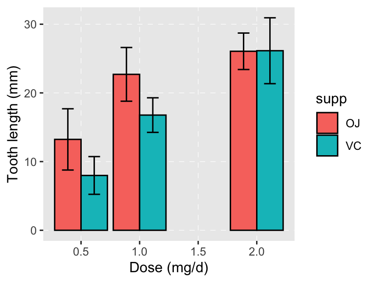